# POWER

Laurel Brehm & Eirini Zormpa

6/6/2019

## What is power?

Let’s start out with some nuts and bolts!

## NHST

We are working under the null hypothesis significance testing framework = the type of stats you probably learned in school

H0 is our null hypothesis. For example…

- H0 = stats are boring
- H1 = stats are not boring

## NHST

We assess whether data are covered under the null hypothesis, and try to reject it if we can.

We do so by looking at whether the data are likely under the null hypothesis

- p-value = how likely is it that these data are true, given H0

The typical threshold that is set is p < 0.05

- A value with p < 0.05 is a ‘significant’ value
- p < 0.05 = an outcome unlikely under the null hypothesis.

## Type I error

An outcome unlikely under the null hypothesis is still *possible*

In fact, it occurs alpha ($\alpha$)% of the time – 5% of cases!

- Type I error – a false positive (‘I found it’ error)

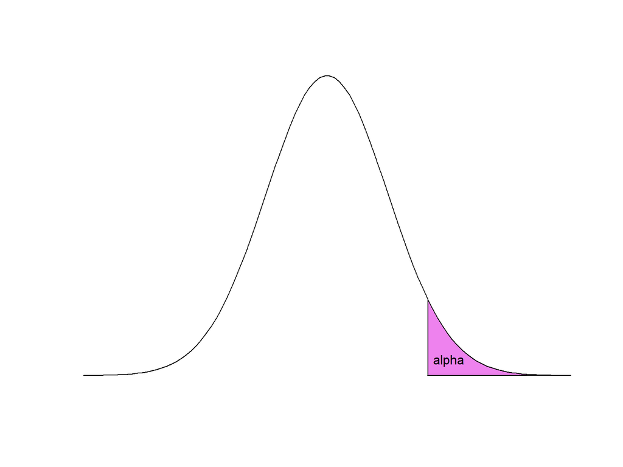

## Beta

But we care about H1 – the alternate hypothesis.

Comparing the distributions gives us beta ($\beta$) = the amount of the H1 curve below the $\alpha$ threshold.

This is when we fail to reject H0 when in fact, H1 is true.

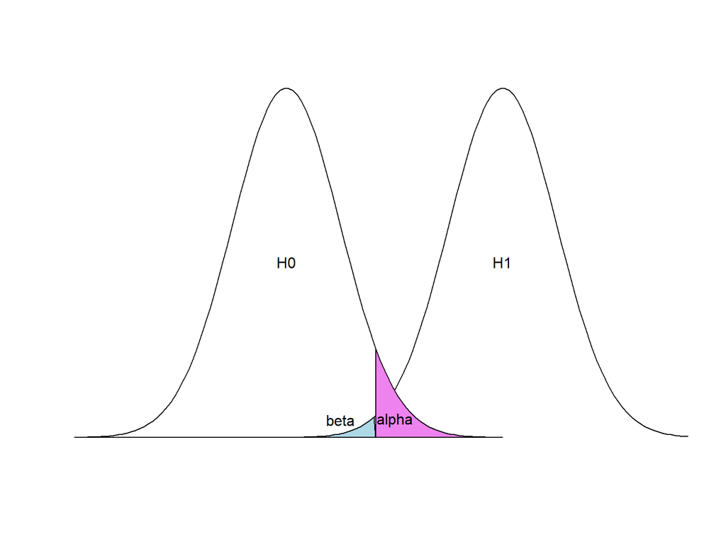

## Bad betas and betta betas

$\beta$ is the false negative rate (type II or “2 bad ya missed it” error).

If H0 and H1 are very different, $\beta$ will be small = few false negatives.

If H0 and H1 are very similar, $\beta$ will be large = many false negatives.

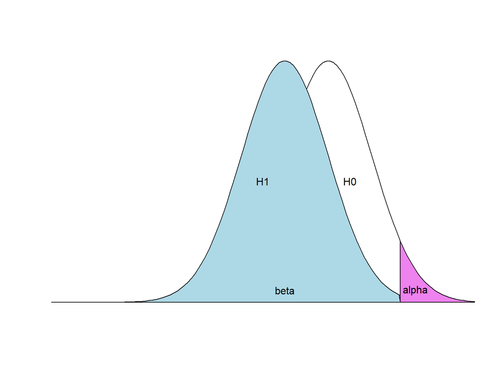

## Power is 1 - Beta

Power is mathematically defined as 1-$\beta$.

It is the ability to correctly reject H0, the null hypothesis = to find the truth!

Maximise power by minimising false negatives.

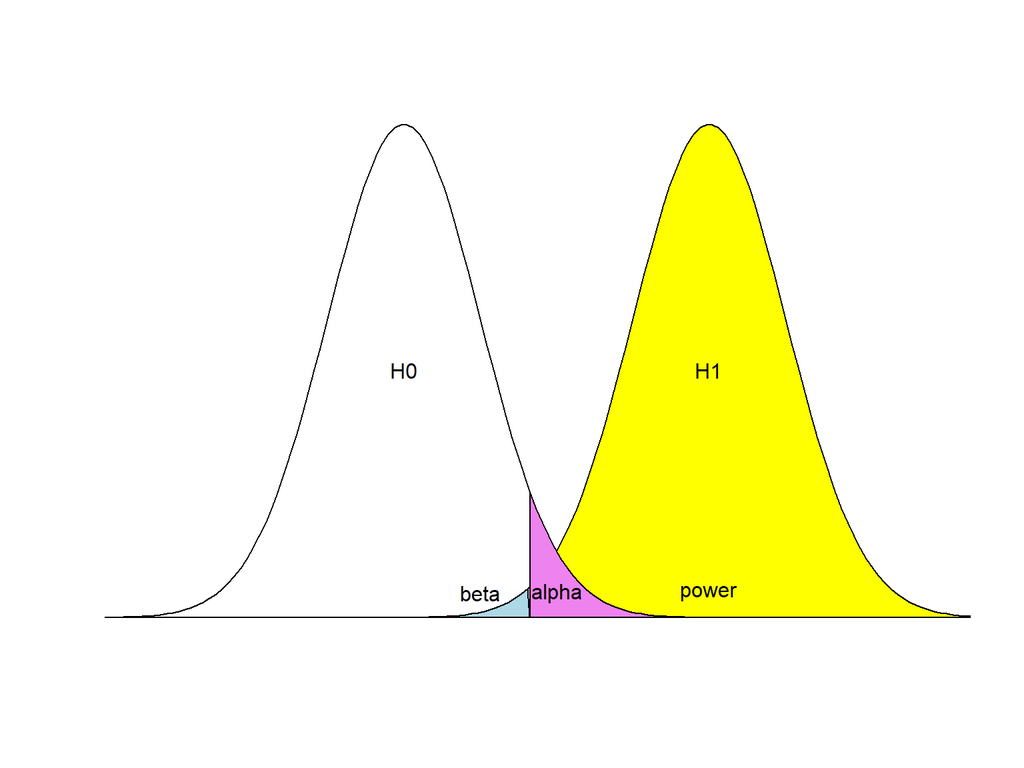

## Sample size and variability

Power relates to sample size because sampling is variable.

With small sample size, the estimate of the H1 mean is not very precise.

Look at how the mean (heavy line) bounces around… This could over-inflate our power estimate.

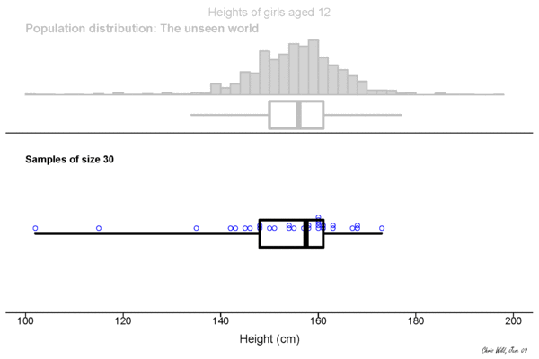

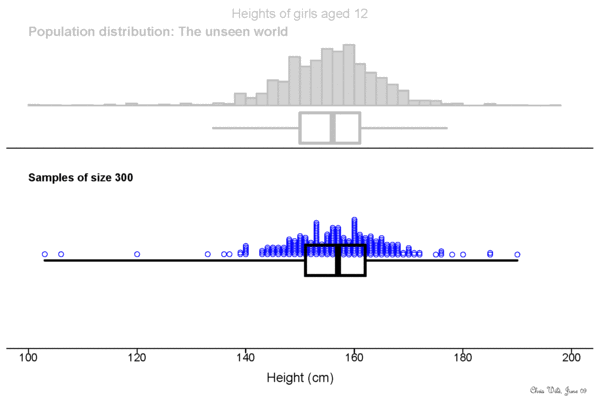

https://www.stat.auckland.ac.nz/~wild/WPRH/

## Sample size and variability

With small samples, the estimate of the H1 error is also less precise.

Look at how the rectangle (interquartile interval) changes in size more on the left… This decreases power.

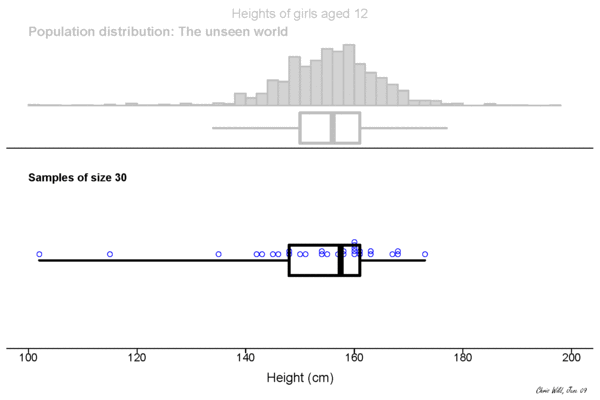

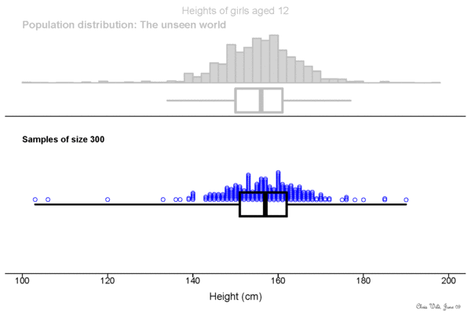

https://www.stat.auckland.ac.nz/~wild/WPRH/

## Maximising power

So, to run a study with sufficient power, you need to do 2 things:

# Replicability

## What is replicability?

[According to the American Statistical Association](https://www.amstat.org/asa/files/pdfs/POL-ReproducibleResearchRecommendations.pdf):

“[…]the act of repeating an entire study, independently of the original investigator without the use of original data (but generally using the same methods).”

## Power and replicability

- Low power can decrease the likelihood that a statistically significant effect is a true effect, e.g. see Ioannidis (2005).
- Even when low-powered studies report true effects, their sizes tend to be exaggerated

## Example 1

[figure not shown]

For the [full article](https://www.nature.com/articles/nrn3502) see Button et al. (2013).

## Example 2

[figure not shown]

For the [full article](https://www.theatlantic.com/science/archive/2019/05/waste-1000-studies/589684/) see Yong (2019).

## It’s not all bad!

One way to combat these problems are Registered Reports

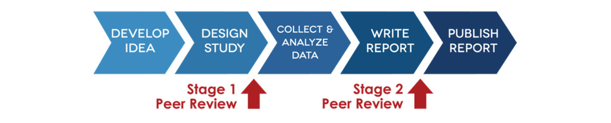

https://cos.io/rr/

## RRs: publication bias

[figure not shown]

For the [article](https://www.nature.com/articles/d41586-018-07118-1) see Warren (2018) and for the [preprint](https://psyarxiv.com/3czyt) it’s based on see Allen and Mehler (2018).

## RRs: effect size estimates

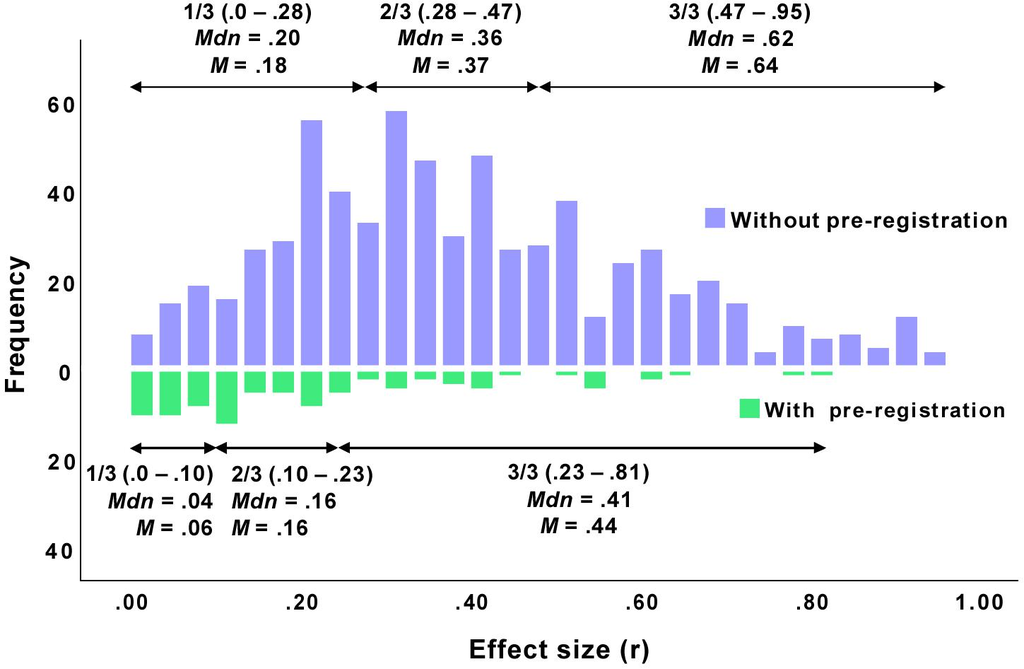

For the [full article](https://www.frontiersin.org/articles/10.3389/fpsyg.2019.00813/full) see Schäfer and Schwarz (2019).

## How to power?

- G*Power
- pwr
- simulations
- pragmatic restrictions

## References

Allen, Christopher, and David Mehler. 2018. “Open Science Challenges, Benefits and Tips in Early Career and Beyond.” *PsyArXiv Preprints*, November. doi:10.31234/osf.io/3czyt.

Button, Katherine S., John P. A. Ioannidis, Claire Mokrysz, Brian A. Nosek, Jonathan Flint, Emma S. J. Robinson, and Marcus R. Munafò. 2013. “Power Failure: Why Small Sample Size Undermines the Reliability of Neuroscience.” *Nature Reviews Neuroscience* 14 (5): 365–76. doi:10.1038/nrn3475.

Ioannidis, John P. A. 2005. “Why Most Published Research Findings Are False.” *PLOS Medicine* 2 (8): e124. doi:10.1371/journal.pmed.0020124.

Schäfer, Thomas, and Marcus A. Schwarz. 2019. “The Meaningfulness of Effect Sizes in Psychological Research: Differences Between Sub-Disciplines and the Impact of Potential Biases.” *Frontiers in Psychology* 10: 813. doi:10.3389/fpsyg.2019.00813.

Warren, Matthew. 2018. “First Analysis of Pre-Registered’ Studies Shows Sharp Rise in Null Findings.” Edited by nature.com. doi:10.1038/d41586-018-07118-1.

Yong, Ed. 2019. “A Waste of 1,000 Research Papers.” Edited by theatlantic.com. https://www.theatlantic.com/science/archive/2019/05/waste-1000-studies/589684/.